# Week 15: Comprehensive Final Exam Review

Complete Course Review for ISM4641

Instructor: Dr. Smith • Version: 0.12.0 • University of South Florida

# Comprehensive Final Exam Review

## Exam Overview

The final exam is cumulative, covering all material from Weeks 1-13 with emphasis on: - **40%** Advanced Topics (Weeks 7-13): Pandas, Matplotlib, Statistics, Machine Learning - **35%** Core Python (Weeks 1-6): Fundamentals, Data Structures, Functions, NumPy - **25%** Integrated Applications: Combining multiple concepts

## Part 1: Python Fundamentals (Weeks 1-3)

### 1.1 Variables and Data Types

```python
# Core data types you must know
data_types = {
    'int': 42,
    'float': 3.14,
    'str': "Hello",
    'bool': True,
    'list': [1, 2, 3],
    'tuple': (1, 2, 3),
    'dict': {'key': 'value'},
    'set': {1, 2, 3}
}

# Type conversion - Know these!
str_to_int = int("42")
int_to_float = float(5)
list_to_set = set([1, 2, 2, 3])  # Removes duplicates
print(f"Set from list: {list_to_set}")
```

```
Set from list: {1, 2, 3}
```

### 1.2 Control Flow

```python
# If-elif-else structure
def grade_classifier(score):
    if score >= 90:
        return 'A'
    elif score >= 80:
        return 'B'
    elif score >= 70:
        return 'C'
    elif score >= 60:
        return 'D'
    else:
        return 'F'

# Loops - for and while
# For loop with enumerate
items = ['apple', 'banana', 'cherry']
for index, item in enumerate(items):
    print(f"{index}: {item}")

# List comprehension (IMPORTANT!)
squares = [x**2 for x in range(5)]
even_squares = [x**2 for x in range(10) if x % 2 == 0]
print(f"Even squares: {even_squares}")
```

```
0: apple
1: banana
2: cherry
Even squares: [0, 4, 16, 36, 64]
```

### 1.3 Data Structures

```python
# Lists - ordered, mutable
my_list = [1, 2, 3]
my_list.append(4)
my_list.extend([5, 6])
my_list.insert(0, 0)  # Insert at index 0

# Dictionaries - key-value pairs
student = {
    'name': 'John',
    'age': 20,
    'grades': [85, 90, 88]
}
# Dictionary methods
print(f"Keys: {student.keys()}")
print(f"Values: {student.values()}")
print(f"Items: {list(student.items())[:2]}")  # First 2 items

# Sets - unique elements, unordered
set_a = {1, 2, 3}
set_b = {2, 3, 4}
print(f"Union: {set_a | set_b}")
print(f"Intersection: {set_a & set_b}")
print(f"Difference: {set_a - set_b}")
```

```
Keys: dict_keys(['name', 'age', 'grades'])
Values: dict_values(['John', 20, [85, 90, 88]])
Items: [('name', 'John'), ('age', 20)]
Union: {1, 2, 3, 4}
Intersection: {2, 3}
Difference: {1}
```

**Key Concepts to Remember**

- **Lists** are mutable, **tuples** are immutable
- **Dictionary keys** must be immutable (strings, numbers, tuples)
- **Sets** automatically remove duplicates
- **List comprehensions** are faster than loops

## Part 2: Functions and Modules (Week 4)

### 2.1 Function Definition

```python
# Function with multiple features
def analyze_data(data, threshold=0, operation='sum', *args, **kwargs):
    """
    Comprehensive function example showing all parameter types
    """
    # Filter data based on threshold
    filtered = [x for x in data if x > threshold]

    # Perform operation
    if operation == 'sum':
        result = sum(filtered)
    elif operation == 'mean':
        result = sum(filtered) / len(filtered) if filtered else 0
    elif operation == 'max':
        result = max(filtered) if filtered else None
    else:
        result = filtered

    # Handle additional arguments
    if args:
        print(f"Additional args: {args}")
    if kwargs:
        print(f"Keyword args: {kwargs}")

    return result

# Test the function
data = [1, 5, 3, 8, 2, 9]
result = analyze_data(data, threshold=3, operation='mean',
                     extra_arg=True, verbose=True)
print(f"Result: {result}")
```

```
Keyword args: {'extra_arg': True, 'verbose': True}
Result: 7.333333333333333
```

### 2.2 Lambda Functions

```python
# Lambda functions for quick operations
square = lambda x: x**2
add = lambda x, y: x + y

# Using lambda with map, filter, reduce
numbers = [1, 2, 3, 4, 5]

# Map: apply function to all elements
squared = list(map(lambda x: x**2, numbers))
print(f"Squared: {squared}")

# Filter: keep elements that satisfy condition
evens = list(filter(lambda x: x % 2 == 0, numbers))
print(f"Evens: {evens}")

# Reduce: cumulative operation
from functools import reduce
product = reduce(lambda x, y: x * y, numbers)
print(f"Product: {product}")
```

```
Squared: [1, 4, 9, 16, 25]
Evens: [2, 4]
Product: 120
```

## Part 3: NumPy (Week 5)

### 3.1 Array Operations

```python
import numpy as np

# Array creation
arr1 = np.array([1, 2, 3, 4, 5])
arr2 = np.arange(0, 10, 2)  # 0 to 10, step 2
arr3 = np.linspace(0, 1, 5)  # 5 evenly spaced points

# 2D arrays
matrix = np.array([[1, 2, 3],
                   [4, 5, 6],
                   [7, 8, 9]])

# Array operations (vectorized)
print(f"Element-wise multiplication: {arr1 * 2}")
print(f"Array sum: {arr1.sum()}")
print(f"Array mean: {arr1.mean()}")
print(f"Array std: {arr1.std():.2f}")

# Indexing and slicing
print(f"Matrix row 0: {matrix[0]}")
print(f"Matrix column 1: {matrix[:, 1]}")
print(f"Matrix subarray: {matrix[:2, :2]}")
```

```
Element-wise multiplication: [ 2  4  6  8 10]
Array sum: 15
Array mean: 3.0
Array std: 1.41
Matrix row 0: [1 2 3]
Matrix column 1: [2 5 8]
Matrix subarray: [[1 2]
 [4 5]]
```

### 3.2 Broadcasting and Reshaping

```python
# Broadcasting - operations between different shaped arrays
vector = np.array([1, 2, 3])
matrix = np.array([[1, 2, 3],
                   [4, 5, 6]])

# Broadcasting vector to matrix
result = matrix + vector  # Adds vector to each row
print(f"Broadcasting result:\n{result}")

# Reshaping
arr = np.arange(12)
reshaped = arr.reshape(3, 4)
print(f"Reshaped to 3x4:\n{reshaped}")

# Common array methods
print(f"Shape: {reshaped.shape}")
print(f"Size: {reshaped.size}")
print(f"Dimensions: {reshaped.ndim}")
```

```
Broadcasting result:
[[2 4 6]
 [5 7 9]]
Reshaped to 3x4:
[[ 0  1  2  3]
 [ 4  5  6  7]
 [ 8  9 10 11]]
Shape: (3, 4)
Size: 12
Dimensions: 2
```

## Part 4: Pandas (Week 7)

### 4.1 DataFrame Operations

```python
import pandas as pd

# Creating DataFrames
data = {
    'Name': ['Alice', 'Bob', 'Charlie', 'David'],
    'Age': [25, 30, 35, 28],
    'Salary': [50000, 60000, 75000, 55000],
    'Department': ['IT', 'HR', 'IT', 'Finance']
}
df = pd.DataFrame(data)

# Basic operations
print(f"Shape: {df.shape}")
print(f"Columns: {list(df.columns)}")
print(f"Data types:\n{df.dtypes}")

# Selection and filtering
it_employees = df[df['Department'] == 'IT']
high_earners = df[df['Salary'] > 55000]
print(f"\nIT Employees:\n{it_employees}")

# Aggregation
dept_stats = df.groupby('Department').agg({
    'Salary': ['mean', 'max'],
    'Age': 'mean'
})
print(f"\nDepartment Statistics:\n{dept_stats}")
```

```
Shape: (4, 4)
Columns: ['Name', 'Age', 'Salary', 'Department']
Data types:
Name          object
Age            int64
Salary         int64
Department    object
dtype: object

IT Employees:
      Name  Age  Salary Department
0    Alice   25   50000         IT
2  Charlie   35   75000         IT

Department Statistics:
             Salary          Age
               mean    max  mean
Department
Finance     55000.0  55000  28.0
HR          60000.0  60000  30.0
IT          62500.0  75000  30.0
```

### 4.2 Data Manipulation

```python
# Adding new columns
df['Bonus'] = df['Salary'] * 0.1
df['Total_Comp'] = df['Salary'] + df['Bonus']

# Sorting
df_sorted = df.sort_values('Total_Comp', ascending=False)
print(f"Sorted by compensation:\n{df_sorted[['Name', 'Total_Comp']]}")

# Handling missing data
df_with_nan = df.copy()
df_with_nan.loc[1, 'Salary'] = np.nan

# Fill missing values
df_filled = df_with_nan.fillna(df_with_nan['Salary'].mean())

# Apply functions
df['Salary_Category'] = df['Salary'].apply(
    lambda x: 'High' if x > 60000 else 'Medium' if x > 50000 else 'Low'
)
print(f"\nSalary categories:\n{df[['Name', 'Salary', 'Salary_Category']]}")
```

```
Sorted by compensation:
      Name  Total_Comp
2  Charlie     82500.0
1      Bob     66000.0
3    David     60500.0
0    Alice     55000.0

Salary categories:
      Name  Salary Salary_Category
0    Alice   50000             Low
1      Bob   60000          Medium
2  Charlie   75000            High
3    David   55000          Medium
```

## Part 5: Data Visualization (Week 8)

### 5.1 Matplotlib Basics

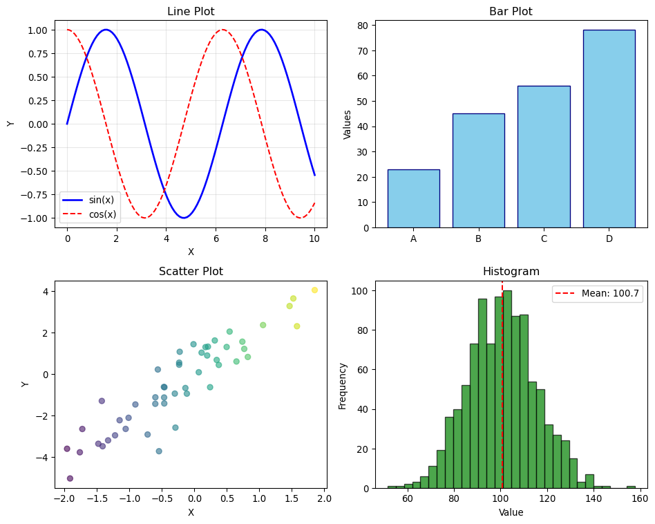

```python
import matplotlib.pyplot as plt

# Create sample data
x = np.linspace(0, 10, 100)
y1 = np.sin(x)
y2 = np.cos(x)

# Create subplots
fig, axes = plt.subplots(2, 2, figsize=(10, 8))

# Line plot
axes[0, 0].plot(x, y1, label='sin(x)', color='blue', linewidth=2)
axes[0, 0].plot(x, y2, label='cos(x)', color='red', linestyle='--')
axes[0, 0].set_title('Line Plot')
axes[0, 0].set_xlabel('X')
axes[0, 0].set_ylabel('Y')
axes[0, 0].legend()
axes[0, 0].grid(True, alpha=0.3)

# Bar plot
categories = ['A', 'B', 'C', 'D']
values = [23, 45, 56, 78]
axes[0, 1].bar(categories, values, color='skyblue', edgecolor='navy')
axes[0, 1].set_title('Bar Plot')
axes[0, 1].set_ylabel('Values')

# Scatter plot
np.random.seed(42)
x_scatter = np.random.randn(50)
y_scatter = 2 * x_scatter + np.random.randn(50)
axes[1, 0].scatter(x_scatter, y_scatter, alpha=0.6, c=x_scatter, cmap='viridis')
axes[1, 0].set_title('Scatter Plot')
axes[1, 0].set_xlabel('X')
axes[1, 0].set_ylabel('Y')

# Histogram
data = np.random.normal(100, 15, 1000)
axes[1, 1].hist(data, bins=30, color='green', alpha=0.7, edgecolor='black')
axes[1, 1].set_title('Histogram')
axes[1, 1].set_xlabel('Value')
axes[1, 1].set_ylabel('Frequency')
axes[1, 1].axvline(data.mean(), color='red', linestyle='--',
                   label=f'Mean: {data.mean():.1f}')
axes[1, 1].legend()

plt.tight_layout()
plt.show()
```

### 5.2 Visualization Best Practices

**Visualization Checklist**

✅ **Always include:** - Title - Axis labels with units - Legend (if multiple series) - Appropriate color scheme - Grid for readability

❌ **Avoid:** - 3D plots (unless necessary) - Too many colors - Overlapping labels - Missing context

## Part 6: Statistics (Weeks 9-10)

### 6.1 Descriptive Statistics

```python
from scipy import stats

# Generate sample data
np.random.seed(42)
data = np.random.normal(100, 15, 1000)

# Descriptive statistics
statistics = {
    'Mean': np.mean(data),
    'Median': np.median(data),
    'Mode': stats.mode(data, keepdims=True)[0][0],
    'Std Dev': np.std(data, ddof=1),  # Sample std
    'Variance': np.var(data, ddof=1),
    'Min': np.min(data),
    'Max': np.max(data),
    'Q1': np.percentile(data, 25),
    'Q3': np.percentile(data, 75),
    'IQR': np.percentile(data, 75) - np.percentile(data, 25),
    'Skewness': stats.skew(data),
    'Kurtosis': stats.kurtosis(data)
}

for stat, value in statistics.items():
    print(f"{stat:12s}: {value:8.2f}")
```

```
Mean        :   100.29
Median      :   100.38
Mode        :    51.38
Std Dev     :    14.69
Variance    :   215.74
Min         :    51.38
Max         :   157.79
Q1          :    90.29
Q3          :   109.72
IQR         :    19.43
Skewness    :     0.12
Kurtosis    :     0.07
```

### 6.2 Hypothesis Testing

```python
# T-test example
group1 = np.random.normal(100, 15, 100)
group2 = np.random.normal(105, 15, 100)

# Perform t-test
t_stat, p_value = stats.ttest_ind(group1, group2)
print(f"T-statistic: {t_stat:.4f}")
print(f"P-value: {p_value:.4f}")

alpha = 0.05
if p_value < alpha:
    print(f"Reject null hypothesis (p={p_value:.4f} < {alpha})")
    print("Groups are significantly different")
else:
    print(f"Fail to reject null hypothesis (p={p_value:.4f} >= {alpha})")
    print("No significant difference between groups")

# Confidence interval
mean = np.mean(group1)
sem = stats.sem(group1)  # Standard error
confidence = 0.95
ci = stats.t.interval(confidence, len(group1)-1, loc=mean, scale=sem)
print(f"\n95% Confidence Interval: [{ci[0]:.2f}, {ci[1]:.2f}]")
```

```
T-statistic: -1.9192
P-value: 0.0564
Fail to reject null hypothesis (p=0.0564 >= 0.05)
No significant difference between groups

95% Confidence Interval: [99.57, 105.23]
```

## Part 7: Machine Learning (Weeks 11-12)

### 7.1 Linear Regression

```python
from sklearn.model_selection import train_test_split
from sklearn.linear_model import LinearRegression
from sklearn.metrics import mean_squared_error, r2_score

# Generate sample data
np.random.seed(42)
X = np.random.rand(100, 3)  # 3 features
y = 5 + 2*X[:, 0] + 3*X[:, 1] - 1*X[:, 2] + np.random.randn(100)*0.5

# Train-test split
X_train, X_test, y_train, y_test = train_test_split(
    X, y, test_size=0.2, random_state=42
)

# Train model
model = LinearRegression()
model.fit(X_train, y_train)

# Make predictions
y_pred = model.predict(X_test)

# Evaluate
mse = mean_squared_error(y_test, y_pred)
r2 = r2_score(y_test, y_pred)

print(f"Coefficients: {model.coef_}")
print(f"Intercept: {model.intercept_:.2f}")
print(f"MSE: {mse:.4f}")
print(f"R-squared: {r2:.4f}")
```

```
Coefficients: [ 2.05294884  2.962303   -0.65697038]
Intercept: 4.96
MSE: 0.5043
R-squared: 0.7100
```

### 7.2 Logistic Regression

```python
from sklearn.linear_model import LogisticRegression
from sklearn.metrics import confusion_matrix, classification_report

# Generate binary classification data
np.random.seed(42)
X_class = np.random.randn(200, 2)
y_class = (X_class[:, 0] + X_class[:, 1] > 0).astype(int)

# Add some noise
noise_indices = np.random.choice(200, 20, replace=False)
y_class[noise_indices] = 1 - y_class[noise_indices]

# Split data
X_train_c, X_test_c, y_train_c, y_test_c = train_test_split(
    X_class, y_class, test_size=0.3, random_state=42
)

# Train logistic regression
clf = LogisticRegression(random_state=42)
clf.fit(X_train_c, y_train_c)

# Predictions
y_pred_c = clf.predict(X_test_c)

# Confusion matrix
cm = confusion_matrix(y_test_c, y_pred_c)
print("Confusion Matrix:")
print(cm)

# Classification metrics
from sklearn.metrics import accuracy_score, precision_score, recall_score, f1_score

metrics = {
    'Accuracy': accuracy_score(y_test_c, y_pred_c),
    'Precision': precision_score(y_test_c, y_pred_c),
    'Recall': recall_score(y_test_c, y_pred_c),
    'F1-Score': f1_score(y_test_c, y_pred_c)
}

print("\nClassification Metrics:")
for metric, value in metrics.items():
    print(f"{metric:10s}: {value:.4f}")
```

```
Confusion Matrix:
[[30  0]
 [ 5 25]]

Classification Metrics:
Accuracy  : 0.9167
Precision : 1.0000
Recall    : 0.8333
F1-Score  : 0.9091
```

## Part 8: Model Evaluation (Week 13)

### 8.1 Key Metrics Summary

**Classification Metrics Formulas**

**Confusion Matrix Components:** - True Positives (TP): Correctly predicted positive - True Negatives (TN): Correctly predicted negative - False Positives (FP): Incorrectly predicted positive - False Negatives (FN): Incorrectly predicted negative

**Metrics:** - **Accuracy** = (TP + TN) / (TP + TN + FP + FN) - **Precision** = TP / (TP + FP) - **Recall** = TP / (TP + FN) - **F1-Score** = 2 × (Precision × Recall) / (Precision + Recall)

**Regression Metrics:** - **MSE** = Σ(y_true - y_pred)² / n - **RMSE** = √MSE - **MAE** = Σ|y_true - y_pred| / n - **R²** = 1 - (SS_res / SS_tot)

### 8.2 Cross-Validation

```python
from sklearn.model_selection import cross_val_score

# Cross-validation for regression
cv_scores = cross_val_score(LinearRegression(), X, y, cv=5,
                           scoring='r2')
print(f"Cross-validation R² scores: {cv_scores}")
print(f"Mean CV Score: {cv_scores.mean():.4f} (+/- {cv_scores.std()*2:.4f})")

# Cross-validation for classification
cv_scores_class = cross_val_score(LogisticRegression(), X_class, y_class,
                                  cv=5, scoring='accuracy')
print(f"\nCross-validation Accuracy: {cv_scores_class.mean():.4f}")
```

```
Cross-validation R² scores: [0.82055843 0.75128618 0.86406402 0.91199398 0.82409312]
Mean CV Score: 0.8344 (+/- 0.1062)

Cross-validation Accuracy: 0.8850
```

## Part 9: Practice Problems

### Problem 1: Data Manipulation

```python
# Given this dataset, complete the tasks
data = {
    'Product': ['A', 'B', 'C', 'D', 'E'],
    'Q1_Sales': [100, 150, 200, 120, 180],
    'Q2_Sales': [110, 140, 210, 130, 190],
    'Q3_Sales': [120, 160, 190, 140, 200],
    'Q4_Sales': [130, 170, 220, 135, 210]
}
df = pd.DataFrame(data)

# Task 1: Calculate total annual sales for each product
df['Annual_Sales'] = df[['Q1_Sales', 'Q2_Sales', 'Q3_Sales', 'Q4_Sales']].sum(axis=1)

# Task 2: Find the best performing quarter for each product
quarters = ['Q1_Sales', 'Q2_Sales', 'Q3_Sales', 'Q4_Sales']
df['Best_Quarter'] = df[quarters].idxmax(axis=1)

# Task 3: Calculate growth rate from Q1 to Q4
df['Growth_Rate'] = ((df['Q4_Sales'] - df['Q1_Sales']) / df['Q1_Sales'] * 100).round(2)

print(df[['Product', 'Annual_Sales', 'Best_Quarter', 'Growth_Rate']])
```

```
  Product  Annual_Sales Best_Quarter  Growth_Rate
0       A           460     Q4_Sales        30.00
1       B           620     Q4_Sales        13.33
2       C           820     Q4_Sales        10.00
3       D           525     Q3_Sales        12.50
4       E           780     Q4_Sales        16.67
```

### Problem 2: Statistical Analysis

```python
# Analyze this sales data
np.random.seed(42)
before_campaign = np.random.normal(1000, 200, 50)
after_campaign = np.random.normal(1100, 250, 50)

# Perform paired t-test
t_stat, p_value = stats.ttest_rel(after_campaign, before_campaign)

print(f"Mean before: ${before_campaign.mean():.2f}")
print(f"Mean after: ${after_campaign.mean():.2f}")
print(f"Increase: ${after_campaign.mean() - before_campaign.mean():.2f}")
print(f"P-value: {p_value:.4f}")

if p_value < 0.05:
    print("✅ Campaign had significant positive effect")
else:
    print("❌ No significant effect from campaign")
```

```
Mean before: $954.91
Mean after: $1104.45
Increase: $149.54
P-value: 0.0003
✅ Campaign had significant positive effect
```

## Part 10: Exam Strategy

### Time Management

- **Read all questions first** (5 minutes)
- **Start with easy questions** to build confidence
- **Allocate time proportionally** to point values
- **Leave 10 minutes** for review

### Common Mistakes to Avoid

**Top 10 Mistakes**

1. **Off-by-one errors** in indexing (Python is 0-indexed!)
2. **Forgetting parentheses** in function calls
3. **Mutable default arguments** in functions
4. **Integer division** when float is needed
5. **Not handling edge cases** (empty lists, None values)
6. **Confusing `=` and `==`** in conditions
7. **Forgetting `self` in class methods**
8. **Not importing required libraries**
9. **Using wrong metric** for the problem
10. **Not reading the full question**

### Quick Reference Syntax

```python
# String formatting
name, age, gpa = "Alice", 20, 3.85
print(f"Student: {name}, Age: {age}, GPA: {gpa:.2f}")

# Error handling
try:
    result = 10 / 0
except ZeroDivisionError:
    print("Cannot divide by zero!")
finally:
    print("Cleanup code here")

# File operations (know the syntax!)
# with open('file.txt', 'r') as f:
#     content = f.read()

# List methods to remember
methods = ['append()', 'extend()', 'insert()', 'remove()',
          'pop()', 'clear()', 'index()', 'count()', 'sort()', 'reverse()']

# Dictionary methods to remember
dict_methods = ['keys()', 'values()', 'items()', 'get()',
               'pop()', 'update()', 'clear()']
```

```
Student: Alice, Age: 20, GPA: 3.85
Cannot divide by zero!
Cleanup code here
```

## Final Checklist

### Must-Know Concepts

✅ **Python Basics** - [ ] Variable types and conversion - [ ] Control flow (if/elif/else, for, while) - [ ] List comprehensions - [ ] Function definition and calls

✅ **Data Structures** - [ ] List operations and methods - [ ] Dictionary operations - [ ] Set operations - [ ] Tuple properties

✅ **NumPy** - [ ] Array creation and indexing - [ ] Broadcasting - [ ] Basic statistics (mean, std, etc.)

✅ **Pandas** - [ ] DataFrame creation and selection - [ ] Groupby and aggregation - [ ] Handling missing data - [ ] Apply and lambda functions

✅ **Visualization** - [ ] Basic plot types - [ ] Subplots - [ ] Labels and legends

✅ **Statistics** - [ ] Descriptive statistics - [ ] Hypothesis testing - [ ] Confidence intervals - [ ] P-values interpretation

✅ **Machine Learning** - [ ] Train/test split - [ ] Linear regression basics - [ ] Logistic regression basics - [ ] Model evaluation metrics

### Formula Sheet

```python
# Statistics Formulas
formulas = {
    'Mean': 'Σx / n',
    'Variance': 'Σ(x - μ)² / (n-1)',  # Sample variance
    'Std Dev': '√Variance',
    'Z-score': '(x - μ) / σ',
    'SEM': 'σ / √n',
    'CI': 'mean ± (t * SEM)',

    # Regression
    'MSE': 'Σ(y_true - y_pred)² / n',
    'R²': '1 - (SS_res / SS_tot)',

    # Classification
    'Accuracy': '(TP + TN) / Total',
    'Precision': 'TP / (TP + FP)',
    'Recall': 'TP / (TP + FN)',
    'F1': '2 * (Prec * Rec) / (Prec + Rec)'
}
```

## Good Luck!

Remember: - **Read carefully** - understand what’s being asked - **Show your work** - partial credit is available - **Check your answers** - ensure they make sense - **Stay calm** - you’ve prepared well!

*Dr. Tim C. Smith ©️2025*  
*University of South Florida, ISM4641 Python for Business Analytics*

ISM4641 Python for Business - Version 0.12.0